# Titanic

Alex Wohletz

October 28, 2016

# Titanic Dataset Machine Learning

In this Kaggle.com competition, the stated evaluation criteria are to predict the passengers who survived or did not survived against the provided test set.

### First we load the packages we will be using to process the data:

```r
require(caret) #Model building
require(AppliedPredictiveModeling) #Visualization
require(ggplot2) #Visualization
require(Amelia) #NA/Missing value visualization
require(mice) #Missing value imputation
require(e1071) #SVM
require(party) #RPART
require(dplyr) #Filtering and cleaning
require(stringr) #String manipulation
require(randomForest) #Random Forest machine learning
library(doSNOW) #Enable more than one core
registerDoSNOW(makeCluster(2, type = "SOCK"))
```

### Using a function borrowed from: [titanictutorial](https://github.com/wehrley/wehrley.github.io/blob/master/SOUPTONUTS.md) and modified to read the data from disc.

```r
readData <- function(path.name, file.name, column.types, missing.types) {
  read.csv(paste(path.name, file.name, sep="") ,
            colClasses=column.types,
            na.strings=missing.types )
}
```

### Assign the variables.

To make our lives easier we will preprocess some of the import so it is in the correct form.

```r
train.column.types <- c('integer',   # PassengerId
                          'integer',    # Survived
                          'factor',    # Pclass
                         'character', # Name
                         'factor',    # Sex
                         'numeric',   # Age
                         'integer',   # SibSp
                         'integer',   # Parch
                         'character', # Ticket
                         'numeric',   # Fare
                         'character', # Cabin
                         'factor')     # Embarked

test.column.types <- train.column.types[-2] #Survived column does not exist in test
train.data.file <- 'TitanicTrain.csv'
test.data.file <- 'TitanicTest.csv'
Titanic.path <- "C:/Users/Alex/OneDrive/MultivariateAnalysis/TitanicHW/"
missing.types <- c("NA", "")
```

### Now we can go ahead and import the data into R

```r
train.data <-  readData(Titanic.path,train.data.file, train.column.types,missing.types)

test.data <- readData(Titanic.path, test.data.file,
                     test.column.types, missing.types)
```

## Data Cleaning

### First let’s take a look at the NA values using the Amelia function

The Ameilia library provides some excellent tools for visualizing and imputing NA values.

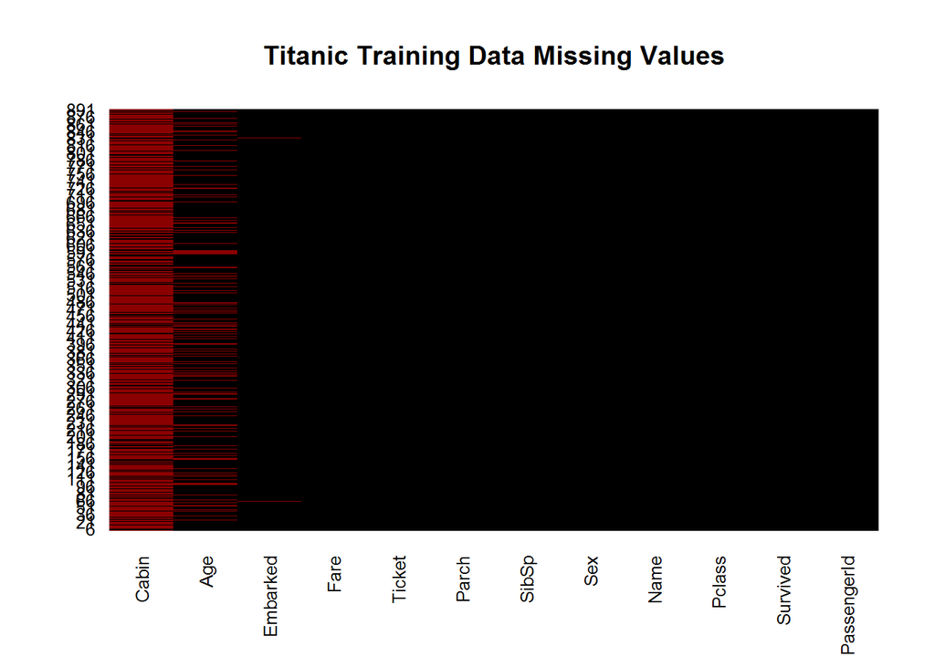

```r
missmap(train.data,col = c("darkred","black"), main = "Titanic Training Data Missing Values",legend = F)
```

There are quite a few missing values in Age and more than 50% data loss in the Cabin variable!

### For ease of cleaning, combine the test and the training data into a single dataframe

```r
test.data$Survived <- 0
combined <- bind_rows(test.data,train.data)
#With so many missing values in the cabin variable, let's just leave it out.
combined <- combined[,-10]
#Take a look at the data.
knitr::kable(head(combined))
```

| PassengerId | Pclass | Name | Sex | Age | SibSp | Parch | Ticket | Fare | Embarked | Survived |
| --- | --- | --- | --- | --- | --- | --- | --- | --- | --- | --- |
| 892 | 3 | Kelly, Mr. James | male | 34.5 | 0 | 0 | 330911 | 7.8292 | Q | 0 |
| 893 | 3 | Wilkes, Mrs. James (Ellen Needs) | female | 47.0 | 1 | 0 | 363272 | 7.0000 | S | 0 |
| 894 | 2 | Myles, Mr. Thomas Francis | male | 62.0 | 0 | 0 | 240276 | 9.6875 | Q | 0 |
| 895 | 3 | Wirz, Mr. Albert | male | 27.0 | 0 | 0 | 315154 | 8.6625 | S | 0 |
| 896 | 3 | Hirvonen, Mrs. Alexander (Helga E Lindqvist) | female | 22.0 | 1 | 1 | 3101298 | 12.2875 | S | 0 |
| 897 | 3 | Svensson, Mr. Johan Cervin | male | 14.0 | 0 | 0 | 7538 | 9.2250 | S | 0 |

```r
str(combined)
```

‘data.frame’: 1309 obs. of 11 variables: $ PassengerId: int 892 893 894 895 896 897 898 899 900 901 … $ Pclass : Factor w/ 3 levels “1”,“2”,“3”: 3 3 2 3 3 3 3 2 3 3 … $ Name : chr “Kelly, Mr. James” “Wilkes, Mrs. James (Ellen Needs)” “Myles, Mr. Thomas Francis” “Wirz, Mr. Albert” … $ Sex : Factor w/ 2 levels “female”,“male”: 2 1 2 2 1 2 1 2 1 2 … $ Age : num 34.5 47 62 27 22 14 30 26 18 21 … $ SibSp : int 0 1 0 0 1 0 0 1 0 2 … $ Parch : int 0 0 0 0 1 0 0 1 0 0 … $ Ticket : chr “330911” “363272” “240276” “315154” … $ Fare : num 7.83 7 9.69 8.66 12.29 … $ Embarked : Factor w/ 3 levels “C”,“Q”,“S”: 2 3 2 3 3 3 2 3 1 3 … $ Survived : num 0 0 0 0 0 0 0 0 0 0 …

```r
knitr::kable(summary(combined))
```

|  | PassengerId | Pclass | Name | Sex | Age | SibSp | Parch | Ticket | Fare | Embarked | Survived |
| --- | --- | --- | --- | --- | --- | --- | --- | --- | --- | --- | --- |
|  | Min. : 1 | 1:323 | Length:1309 | female:466 | Min. : 0.17 | Min. :0.0000 | Min. :0.000 | Length:1309 | Min. : 0.000 | C :270 | Min. :0.0000 |
|  | 1st Qu.: 328 | 2:277 | Class :character | male :843 | 1st Qu.:21.00 | 1st Qu.:0.0000 | 1st Qu.:0.000 | Class :character | 1st Qu.: 7.896 | Q :123 | 1st Qu.:0.0000 |
|  | Median : 655 | 3:709 | Mode :character | NA | Median :28.00 | Median :0.0000 | Median :0.000 | Mode :character | Median : 14.454 | S :914 | Median :0.0000 |
|  | Mean : 655 | NA | NA | NA | Mean :29.88 | Mean :0.4989 | Mean :0.385 | NA | Mean : 33.295 | NA’s: 2 | Mean :0.2613 |
|  | 3rd Qu.: 982 | NA | NA | NA | 3rd Qu.:39.00 | 3rd Qu.:1.0000 | 3rd Qu.:0.000 | NA | 3rd Qu.: 31.275 | NA | 3rd Qu.:1.0000 |
|  | Max. :1309 | NA | NA | NA | Max. :80.00 | Max. :8.0000 | Max. :9.000 | NA | Max. :512.329 | NA | Max. :1.0000 |
|  | NA | NA | NA | NA | NA’s :263 | NA | NA | NA | NA’s :1 | NA | NA |

### Using the method outlined in the R Machine Learning Cookbook, let’s impute some values

```r
#Impute missing values for Embarked using the most common factor
combined$Embarked[which(is.na(combined$Embarked))] = 'S';

#Do some regex for titles
combined$Name = as.character(combined$Name)
table_words = table(unlist(strsplit(combined$Name, "\\s+")))
sort(table_words[grep('\\.', names(table_words))], decreasing = T)
```

```
##
##       Mr.     Miss.      Mrs.   Master.       Dr.      Rev.      Col.
##       757       260       197        61         8         8         4
##    Major.     Mlle.       Ms.     Capt. Countess.      Don.     Dona.
##         2         2         2         1         1         1         1
## Jonkheer.        L.     Lady.      Mme.      Sir.
##         1         1         1         1         1
```

```r
#Find the missing values in the titles
tb = cbind(combined$Age, str_match(combined$Name,"[a-zA-Z]+\\."))
table(tb[is.na(tb[,1]),2])
```

```
##
##     Dr. Master.   Miss.     Mr.    Mrs.     Ms.
##       1       8      50     176      27       1
```

```r
#Impute missing values in age using an inference based on the titles

#First we create the values to impute into the missing ages
mean.mr = mean(combined$Age[grepl(" Mr\\.",combined$Name) & !is.na(combined$Age)])
mean.mrs = mean(combined$Age[grepl(" Mrs\\.",combined$Name) & !is.na(combined$Age)])
mean.dr = mean(combined$Age[grepl(" Dr\\.",combined$Name) & !is.na(combined$Age)])
mean.miss = mean(combined$Age[grepl(" Miss\\.",combined$Name) & !is.na(combined$Age)])
mean.master = mean(combined$Age[grepl(" Master\\.",combined$Name) & !is.na(combined$Age)])
#Then we impute based on a conditional statement.
combined$Age[grepl(" Mr\\.",combined$Name) & is.na(combined$Age)] = mean.mr
combined$Age[grepl(" Mrs\\.",combined$Name) & is.na(combined$Age)] = mean.mrs
combined$Age[grepl(" Dr\\.",combined$Name) & is.na(combined$Age)] = mean.dr
combined$Age[grepl(" Miss\\.",combined$Name) & is.na(combined$Age)] = mean.miss
combined$Age[grepl(" Master\\.",combined$Name) & is.na(combined$Age)] = mean.master

#Remove the na Fares from the data using the median
combined$Fare[which(is.na(combined$Fare))] <- median(combined$Fare, na.rm = T)
```